# Barbod - Resubmission Challenge Problem 4

## Resubmission - Challenge Problem 4

Barbod Khaleghi

I did the questions before the code part perfectly well. For the code, I had issues with the end section. I have not included the previous part of the code as it was simply missing a lot of the information. This is the case as previously we were unable to import the rpy2 package and thus were unable to do much of the previous work. To make up for this, I will explain every part of the process.

Here, we are simply importing the packages we will need to use later.

```python
import pandas as pd
import collections
import numpy as np
```

Here, I am reading in the data that was used using the function pd.read_csv to assign it to a variable counts_raw. With that dataframe, I am then removing the unneceesary columns that are included, namely 'length' and 'ensgene.' I am also getting rid of zero values and reading in the new data title metadata to set the index of id.

```python
counts_raw = pd.read_csv('GSE37704_featurecounts.csv')

counts_nolen = counts_raw.drop(['length','ensgene'], axis=1)
genes_without_counts = (counts_nolen != 0).any(axis=1)

counts_processed = counts_raw.loc[genes_without_counts]

metadata = pd.read_csv('GSE37704_metadata.csv')
metadata = metadata.set_index('id')

print(counts_raw.head())
print(metadata)
print(counts_processed.head())
```

```
           ensgene  length  SRR493366  SRR493367  SRR493368  SRR493369  \
0  ENSG00000186092     918          0          0          0          0
1  ENSG00000279928     718          0          0          0          0
2  ENSG00000279457    1982         23         28         29         29
3  ENSG00000278566     939          0          0          0          0
4  ENSG00000273547     939          0          0          0          0

   SRR493370  SRR493371
0          0          0
1          0          0
2         28         46
3          0          0
4          0          0
               condition
id
SRR493366  control_sirna
SRR493367  control_sirna
SRR493368  control_sirna
SRR493369       hoxa1_kd
SRR493370       hoxa1_kd
SRR493371       hoxa1_kd
           ensgene  length  SRR493366  SRR493367  SRR493368  SRR493369  \
2  ENSG00000279457    1982         23         28         29         29
5  ENSG00000187634    3214        124        123        205        207
6  ENSG00000188976    5539       1637       1831       2383       1226
7  ENSG00000187961    3395        120        153        180        236
8  ENSG00000187583    2833         24         48         65         44

   SRR493370  SRR493371
2         28         46
5        212        258
6       1326       1504
7        255        357
8         48         64
```

The next steps are to parse the dataframe for both the control and hoxal experiments using .loc and .index alongside the list function.

```python
Control_exp = list(metadata.loc[metadata['condition'] == 'control_sirna'].index)
print(Control_exp)

Hoxa1_exp = list(metadata.loc[metadata['condition'] == 'hoxa1_kd'].index)
print(Hoxa1_exp)
```

```
['SRR493366', 'SRR493367', 'SRR493368']
['SRR493369', 'SRR493370', 'SRR493371']
```

After doing so, then I returned a column containing the sum of the reads. Doing so, I also calculated the mean and standard deviation of both of the experiments.

```python
counts_processed['Sum Controls'] = counts_processed[Control_exp].sum(axis=1)
counts_processed['Sum HOXA1 KD'] = counts_processed[Hoxa1_exp].sum(axis=1)
print(counts_processed.head())

counts_processed['Mean Controls'] = counts_processed[Control_exp].mean(axis=1)
counts_processed['Mean HOXA1 KD'] = counts_processed[Hoxa1_exp].mean(axis=1)

counts_processed['STD Controls'] = counts_processed[Control_exp].std(axis=1)
counts_processed['STD HOXA1 KD'] = counts_processed[Hoxa1_exp].std(axis=1)
```

```
           ensgene  length  SRR493366  SRR493367  SRR493368  SRR493369  \
2  ENSG00000279457    1982         23         28         29         29
5  ENSG00000187634    3214        124        123        205        207
6  ENSG00000188976    5539       1637       1831       2383       1226
7  ENSG00000187961    3395        120        153        180        236
8  ENSG00000187583    2833         24         48         65         44

   SRR493370  SRR493371  Sum Controls  Sum HOXA1 KD  Mean Controls  \
2         28         46            80           103      26.666667
5        212        258           452           677     150.666667
6       1326       1504          5851          4056    1950.333333
7        255        357           453           848     151.000000
8         48         64           137           156      45.666667

   Mean HOXA1 KD  STD Controls  STD HOXA1 KD
2      34.333333      3.214550     10.115994
5     225.666667     47.056703     28.112868
6    1352.000000    387.052107    140.811931
7     282.666667     30.049958     65.071755
8      52.000000     20.599353     10.583005
```

[output not shown]

```python
Sum_Dict = {'ensgene': 'total Column Count',
            'length': counts_processed['length'].sum(),
            'SRR493366': counts_processed['SRR493366'].sum(),
            'SRR493367': counts_processed['SRR493367'].sum(),
            'SRR493368': counts_processed['SRR493368'].sum(),
            'SRR493369': counts_processed['SRR493369'].sum(),
            'SRR493370': counts_processed['SRR493370'].sum(),
            'SRR493371': counts_processed['SRR493371'].sum(),
            'Sum Controls': counts_processed['Sum Controls'].sum(),
            'Sum HOXA1 KD': counts_processed['Sum HOXA1 KD'].sum()
           }

counts_processed = counts_processed.append(Sum_Dict, ignore_index = True)
counts_processed = counts_processed.set_index('ensgene')
print(counts_processed)
```

```
                      length  SRR493366  SRR493367  SRR493368  SRR493369  \
ensgene
ENSG00000279457         1982         23         28         29         29
ENSG00000187634         3214        124        123        205        207
ENSG00000188976         5539       1637       1831       2383       1226
ENSG00000187961         3395        120        153        180        236
ENSG00000187583         2833         24         48         65         44
...                      ...        ...        ...        ...        ...
ENSG00000278817         1213          3          1          4          1
ENSG00000278384         3027          0          1          2          1
ENSG00000276345          740         72         73         91         55
ENSG00000271254         4520        188        211        222        148
total Column Count  88323640   12795524   14555994   18416808   15133085

                    SRR493370  SRR493371  Sum Controls  Sum HOXA1 KD  \
ensgene
ENSG00000279457            28         46            80           103
ENSG00000187634           212        258           452           677
ENSG00000188976          1326       1504          5851          4056
ENSG00000187961           255        357           453           848
ENSG00000187583            48         64           137           156
...                       ...        ...           ...           ...
ENSG00000278817             2          4             8             7
ENSG00000278384             2          1             3             4
ENSG00000276345            67         87           236           209
ENSG00000271254           150        161           621           459
total Column Count   16917477   19604703      45768326      51655265

                    Mean Controls  Mean HOXA1 KD  STD Controls  STD HOXA1 KD
ensgene
ENSG00000279457         26.666667      34.333333      3.214550     10.115994
ENSG00000187634        150.666667     225.666667     47.056703     28.112868
ENSG00000188976       1950.333333    1352.000000    387.052107    140.811931
ENSG00000187961        151.000000     282.666667     30.049958     65.071755
ENSG00000187583         45.666667      52.000000     20.599353     10.583005
...                           ...            ...           ...           ...
ENSG00000278817          2.666667       2.333333      1.527525      1.527525
ENSG00000278384          1.000000       1.333333      1.000000      0.577350
ENSG00000276345         78.666667      69.666667     10.692677     16.165808
ENSG00000271254        207.000000     153.000000     17.349352      7.000000
total Column Count            NaN            NaN           NaN           NaN

[15976 rows x 13 columns]
```

Below, I am calculating the FPKM of both of the experiments using the function to combine multiple of the factors in the columns alongisde the 10 ** 9 that is required.

```python
counts_processed['FPKM_controls'] = ((counts_processed['Sum Controls'] * (10 ** 9)))/(counts_processed['length'] * (counts_processed.loc['total Column Count']['Sum Controls']))
counts_processed['FPKM_HOXA1'] = ((counts_processed['Sum HOXA1 KD'] * (10 ** 9)))/(counts_processed['length'] * (counts_processed.loc['total Column Count']['Sum HOXA1 KD']))
print(counts_processed.head())
```

```
                 length  SRR493366  SRR493367  SRR493368  SRR493369  \
ensgene
ENSG00000279457    1982         23         28         29         29
ENSG00000187634    3214        124        123        205        207
ENSG00000188976    5539       1637       1831       2383       1226
ENSG00000187961    3395        120        153        180        236
ENSG00000187583    2833         24         48         65         44

                 SRR493370  SRR493371  Sum Controls  Sum HOXA1 KD  \
ensgene
ENSG00000279457         28         46            80           103
ENSG00000187634        212        258           452           677
ENSG00000188976       1326       1504          5851          4056
ENSG00000187961        255        357           453           848
ENSG00000187583         48         64           137           156

                 Mean Controls  Mean HOXA1 KD  STD Controls  STD HOXA1 KD  \
ensgene
ENSG00000279457      26.666667      34.333333      3.214550     10.115994
ENSG00000187634     150.666667     225.666667     47.056703     28.112868
ENSG00000188976    1950.333333    1352.000000    387.052107    140.811931
ENSG00000187961     151.000000     282.666667     30.049958     65.071755
ENSG00000187583      45.666667      52.000000     20.599353     10.583005

                 FPKM_controls  FPKM_HOXA1
ensgene
ENSG00000279457       0.881904    1.006049
ENSG00000187634       3.072752    4.077821
ENSG00000188976      23.079888   14.175944
ENSG00000187961       2.915368    4.835501
ENSG00000187583       1.056596    1.066015
```

This is a calculation of the log fold change based on the equation.

```python
Fold_change = counts_processed['FPKM_HOXA1']/counts_processed['FPKM_controls']
counts_processed['L2F'] = np.log2(Fold_change)
print(counts_processed.head())
```

```
                 length  SRR493366  SRR493367  SRR493368  SRR493369  \
ensgene
ENSG00000279457    1982         23         28         29         29
ENSG00000187634    3214        124        123        205        207
ENSG00000188976    5539       1637       1831       2383       1226
ENSG00000187961    3395        120        153        180        236
ENSG00000187583    2833         24         48         65         44

                 SRR493370  SRR493371  Sum Controls  Sum HOXA1 KD  \
ensgene
ENSG00000279457         28         46            80           103
ENSG00000187634        212        258           452           677
ENSG00000188976       1326       1504          5851          4056
ENSG00000187961        255        357           453           848
ENSG00000187583         48         64           137           156

                 Mean Controls  Mean HOXA1 KD  STD Controls  STD HOXA1 KD  \
ensgene
ENSG00000279457      26.666667      34.333333      3.214550     10.115994
ENSG00000187634     150.666667     225.666667     47.056703     28.112868
ENSG00000188976    1950.333333    1352.000000    387.052107    140.811931
ENSG00000187961     151.000000     282.666667     30.049958     65.071755
ENSG00000187583      45.666667      52.000000     20.599353     10.583005

                 FPKM_controls  FPKM_HOXA1       L2F
ensgene
ENSG00000279457       0.881904    1.006049  0.190007
ENSG00000187634       3.072752    4.077821  0.408267
ENSG00000188976      23.079888   14.175944 -0.703191
ENSG00000187961       2.915368    4.835501  0.729987
ENSG00000187583       1.056596    1.066015  0.012804
```

First, I had to import stats from scripy to start the p-value process. Then, using the imported package, I am able to calculate the p-value using the function given below. Previously, we were unable to calculate the adjusted p-value but now I was able to use these imported packages in order to do so.

```python
from scipy import stats

counts_processed['p-value'] = counts_processed.apply(lambda x: stats.ttest_ind_from_stats(x['Mean Controls'],x['STD Controls'],x['Sum Controls'], x['Mean HOXA1 KD'],x['STD HOXA1 KD'],x['Sum HOXA1 KD'])[1],axis=1)
print(counts_processed.head())
```

```
                 length  SRR493366  SRR493367  SRR493368  SRR493369  \
ensgene
ENSG00000279457    1982         23         28         29         29
ENSG00000187634    3214        124        123        205        207
ENSG00000188976    5539       1637       1831       2383       1226
ENSG00000187961    3395        120        153        180        236
ENSG00000187583    2833         24         48         65         44

                 SRR493370  SRR493371  Sum Controls  Sum HOXA1 KD  \
ensgene
ENSG00000279457         28         46            80           103
ENSG00000187634        212        258           452           677
ENSG00000188976       1326       1504          5851          4056
ENSG00000187961        255        357           453           848
ENSG00000187583         48         64           137           156

                 Mean Controls  Mean HOXA1 KD  STD Controls  STD HOXA1 KD  \
ensgene
ENSG00000279457      26.666667      34.333333      3.214550     10.115994
ENSG00000187634     150.666667     225.666667     47.056703     28.112868
ENSG00000188976    1950.333333    1352.000000    387.052107    140.811931
ENSG00000187961     151.000000     282.666667     30.049958     65.071755
ENSG00000187583      45.666667      52.000000     20.599353     10.583005

                 FPKM_controls  FPKM_HOXA1       L2F        p-value
ensgene
ENSG00000279457       0.881904    1.006049  0.190007   6.638249e-10
ENSG00000187634       3.072752    4.077821  0.408267  3.648088e-171
ENSG00000188976      23.079888   14.175944 -0.703191   0.000000e+00
ENSG00000187961       2.915368    4.835501  0.729987  6.544165e-235
ENSG00000187583       1.056596    1.066015  0.012804   8.599871e-04
```

```python
from statsmodels.sandbox.stats.multicomp import multipletests
pd.set_option('display.float_format', lambda x: '%.20f' % x)
counts_processed['adjusted-p-value'] = multipletests(counts_processed['p-value'], alpha=.05, method='bonferroni')[1]
print(counts_processed)
```

```
                      length  SRR493366  SRR493367  SRR493368  SRR493369  \
ensgene
ENSG00000279457         1982         23         28         29         29
ENSG00000187634         3214        124        123        205        207
ENSG00000188976         5539       1637       1831       2383       1226
ENSG00000187961         3395        120        153        180        236
ENSG00000187583         2833         24         48         65         44
...                      ...        ...        ...        ...        ...
ENSG00000278817         1213          3          1          4          1
ENSG00000278384         3027          0          1          2          1
ENSG00000276345          740         72         73         91         55
ENSG00000271254         4520        188        211        222        148
total Column Count  88323640   12795524   14555994   18416808   15133085

                    SRR493370  SRR493371  Sum Controls  Sum HOXA1 KD  \
ensgene
ENSG00000279457            28         46            80           103
ENSG00000187634           212        258           452           677
ENSG00000188976          1326       1504          5851          4056
ENSG00000187961           255        357           453           848
ENSG00000187583            48         64           137           156
...                       ...        ...           ...           ...
ENSG00000278817             2          4             8             7
ENSG00000278384             2          1             3             4
ENSG00000276345            67         87           236           209
ENSG00000271254           150        161           621           459
total Column Count   16917477   19604703      45768326      51655265

                               Mean Controls             Mean HOXA1 KD  \
ensgene
ENSG00000279457      26.66666666666666785090   34.33333333333333570181
ENSG00000187634     150.66666666666665719276  225.66666666666665719276
ENSG00000188976    1950.33333333333325754211 1352.00000000000000000000
ENSG00000187961     151.00000000000000000000  282.66666666666668561447
ENSG00000187583      45.66666666666666429819   52.00000000000000000000
...                                      ...                       ...
ENSG00000278817       2.66666666666666651864    2.33333333333333348136
ENSG00000278384       1.00000000000000000000    1.33333333333333325932
ENSG00000276345      78.66666666666667140362   69.66666666666667140362
ENSG00000271254     207.00000000000000000000  153.00000000000000000000
```

[output cut: 44 more lines]

```
                         adjusted-p-value
ensgene
ENSG00000279457    0.00001060526629289928
ENSG00000187634    0.00000000000000000000
ENSG00000188976    0.00000000000000000000
ENSG00000187961    0.00000000000000000000
ENSG00000187583    1.00000000000000000000
...                                   ...
ENSG00000278817    1.00000000000000000000
ENSG00000278384    1.00000000000000000000
ENSG00000276345    0.00000015466156526426
ENSG00000271254    0.00000000000000000000
total Column Count                    NaN

[15976 rows x 18 columns]
```

```
Empty DataFrame
Columns: [length, SRR493366, SRR493367, SRR493368, SRR493369, SRR493370, SRR493371, Sum Controls, Sum HOXA1 KD, Mean Controls, Mean HOXA1 KD, STD Controls, STD HOXA1 KD, FPKM_controls, FPKM_HOXA1, L2F, p-value, adjusted-p-value]
Index: []
```

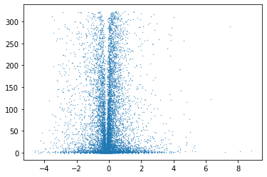

```python
import matplotlib.pyplot as plt
print(counts_processed[counts_processed['adjusted-p-value'].apply(lambda x: isinstance(x, str))])
x = counts_processed['L2F']
y = -(np.log10(counts_processed['p-value']))
plt.scatter(x, y, s=0.1)
plt.show()
```

After creating all of this, I was able to finish by saving the adjusted values as text file to add to the reactome. I previously also did not do this and was just missing this whole part overall.

```python
counts_processed = counts_processed.sort_values(by=['p-value'])
print(counts_processed)
counts_processed.to_csv('ChallengeProblem4_RNAseq_processedcounts.txt', sep='\t')
```

```
                      length  SRR493366  SRR493367  SRR493368  SRR493369  \
ensgene
ENSG00000271254         4520        188        211        222        148
ENSG00000132912         6417       1215       1390       1732       2025
ENSG00000172216         1956        548        597        774       2689
ENSG00000171992        10258       1504       1613       2129        456
ENSG00000070614         9529       5198       6122       7813       4446
...                      ...        ...        ...        ...        ...
ENSG00000183421         4033          0          0          0          0
ENSG00000142182         1859          0          0          0          2
ENSG00000278704         2237          1          0          0          0
ENSG00000277400         2179          0          0          1          0
total Column Count  88323640   12795524   14555994   18416808   15133085

                    SRR493370  SRR493371  Sum Controls  Sum HOXA1 KD  \
ensgene
ENSG00000271254           150        161           621           459
ENSG00000132912          2181       2586          4337          6792
ENSG00000172216          2360       3400          1919          8449
ENSG00000171992           622        517          5246          1595
ENSG00000070614          5176       5592         19133         15214
...                       ...        ...           ...           ...
ENSG00000183421             0          1             0             1
ENSG00000142182             0          0             0             2
ENSG00000278704             0          0             1             0
ENSG00000277400             0          0             1             0
total Column Count   16917477   19604703      45768326      51655265

                               Mean Controls             Mean HOXA1 KD  \
ensgene
ENSG00000271254     207.00000000000000000000  153.00000000000000000000
ENSG00000132912    1445.66666666666674245789 2264.00000000000000000000
ENSG00000172216     639.66666666666662877105 2816.33333333333348491578
ENSG00000171992    1748.66666666666674245789  531.66666666666662877105
ENSG00000070614    6377.66666666666696983157 5071.33333333333303016843
...                                      ...                       ...
ENSG00000183421       0.00000000000000000000    0.33333333333333331483
ENSG00000142182       0.00000000000000000000    0.66666666666666662966
ENSG00000278704       0.33333333333333331483    0.00000000000000000000
ENSG00000277400       0.33333333333333331483    0.00000000000000000000
```

[output cut: 44 more lines]

```
                         adjusted-p-value
ensgene
ENSG00000271254    0.00000000000000000000
ENSG00000132912    0.00000000000000000000
ENSG00000172216    0.00000000000000000000
ENSG00000171992    0.00000000000000000000
ENSG00000070614    0.00000000000000000000
...                                   ...
ENSG00000183421                       NaN
ENSG00000142182                       NaN
ENSG00000278704                       NaN
ENSG00000277400                       NaN
total Column Count                    NaN

[15976 rows x 18 columns]
```